# E8.5 seqFISH - Spatial neighbourhoods and cell compartments using polygon expansion

Shila Ghazanfar

11/06/2020

```r
set.seed(2020)
```

```r
library(SingleCellExperiment)
library(scater)
library(scran)
library(ComplexHeatmap)
library(ggplot2)
library(ggrepel)
library(GGally)
library(limma)
library(patchwork)
library(reshape)
library(gtools)
library(scattermore)
library(gganimate)
library(ggmap)
library(randomForest)
library(batchelor)
library(igraph)
library(cowplot)
library(ggpubr)
```

# Summary

In this report we generate a network object that relates neighbours of cells, by taking the cell segmentation polygon and expanding the vertices by a small expansion factor.

I also contract the cell segmentation

# Background code

Load spatial and segmentation functions

```r
source("spatial_functions.R")
source("segmentation_functions.R")
source("celltype_colours.R")
source("neighbourSegments.R")
```

# Load data

```r
sce_filt = readRDS("../analysis_output/E8.5/E8.5_sce_filt_unlabelled.Rds")
# cData_filt = readRDS("../analysis_output/E8.5/E8.5_cData_filt.Rds")
cData_filt = as.data.frame(colData(sce_filt))
```

Set params

```r
expansionFactor = 1.3
contractionFactor = 0.75
```

Get polygons.

```r
boundary_polygons = getSegmentationVerticesDF(
    colData(sce_filt),
    xname = "segmentation_vertices_x_global_affine",
    yname = "segmentation_vertices_y_global_affine",
    othercols = c("uniqueID", "z", "embryo", "pos"))

dim(boundary_polygons)
```

```
## [1] 2184662       6
```

```r
head(boundary_polygons)
```

```
##                                        uniqueID z  embryo  pos
## embryo1_Pos0_cell10_z2   embryo1_Pos0_cell10_z2 2 embryo1 Pos0
## embryo1_Pos0_cell10_z2.1 embryo1_Pos0_cell10_z2 2 embryo1 Pos0
## embryo1_Pos0_cell10_z2.2 embryo1_Pos0_cell10_z2 2 embryo1 Pos0
## embryo1_Pos0_cell10_z2.3 embryo1_Pos0_cell10_z2 2 embryo1 Pos0
## embryo1_Pos0_cell10_z2.4 embryo1_Pos0_cell10_z2 2 embryo1 Pos0
## embryo1_Pos0_cell10_z2.5 embryo1_Pos0_cell10_z2 2 embryo1 Pos0
##                          segmentation_vertices_x_global_affine
## embryo1_Pos0_cell10_z2                               0.7038363
## embryo1_Pos0_cell10_z2.1                             0.7057894
## embryo1_Pos0_cell10_z2.2                             0.7038363
## embryo1_Pos0_cell10_z2.3                             0.7038363
## embryo1_Pos0_cell10_z2.4                             0.7057894
## embryo1_Pos0_cell10_z2.5                             0.7077426
##                          segmentation_vertices_y_global_affine
## embryo1_Pos0_cell10_z2                               -2.846686
## embryo1_Pos0_cell10_z2.1                             -2.846686
## embryo1_Pos0_cell10_z2.2                             -2.844733
## embryo1_Pos0_cell10_z2.3                             -2.807624
## embryo1_Pos0_cell10_z2.4                             -2.807624
## embryo1_Pos0_cell10_z2.5                             -2.805671
```

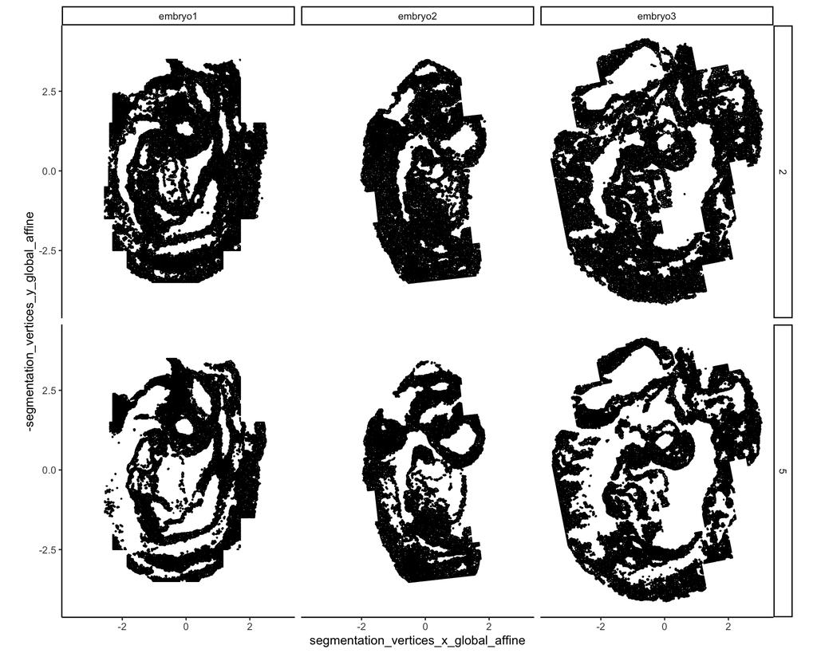

```r
g = ggplot(boundary_polygons,
           aes(x = segmentation_vertices_x_global_affine,
               y = -segmentation_vertices_y_global_affine,
               group = uniqueID)) +
    facet_grid(z ~ embryo) +
    theme_classic() +
    geom_polygon(alpha = 0.5, colour = "black", fill = "lightgrey") +
    coord_fixed() +
    NULL
g
```

# Illustrating polygon expansion using a small example

```r
boundary_polygons_example = subset(boundary_polygons, uniqueID %in%
                                       c("embryo1_Pos0_cell100_z2",
                                         "embryo1_Pos0_cell101_z2"))

length(unique(boundary_polygons_example$uniqueID))
```

```
## [1] 2
```

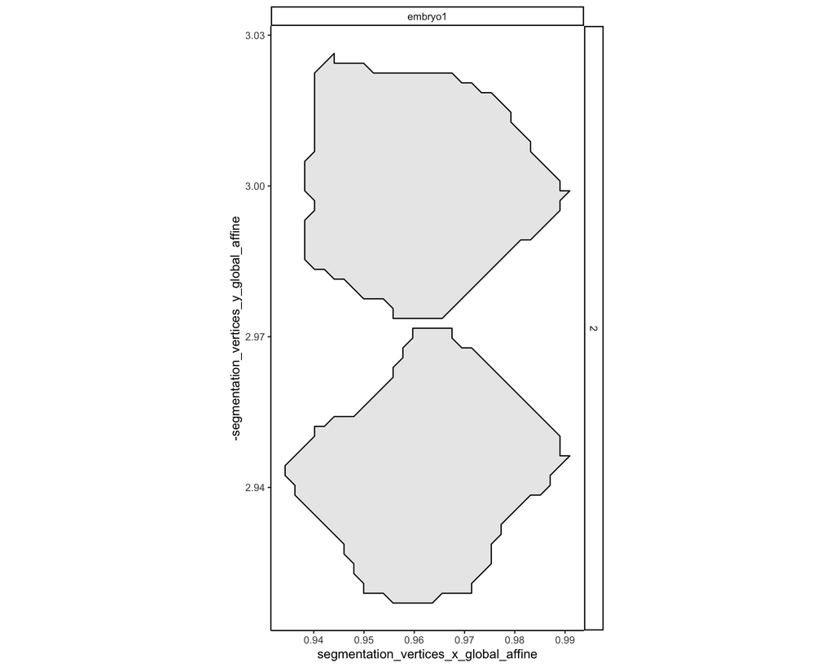

```r
# expansion
boundary_polygons_example <- addExpandedVertices(boundary_polygons_example,
                                                 expansionFactor = expansionFactor)

# contraction
boundary_polygons_example <- addExpandedVertices(boundary_polygons_example,
                                                 expansionFactor = contractionFactor,
                                                 new_xname = "segmentation_vertices_x_global_affine_contracted",
                                                 new_yname = "segmentation_vertices_y_global_affine_contracted")

g = ggplot(boundary_polygons_example,
           aes(x = segmentation_vertices_x_global_affine,
               y = -segmentation_vertices_y_global_affine,
               group = uniqueID)) +
    facet_grid(z ~ embryo) +
    theme_classic() +
    geom_polygon(alpha = 0.5, colour = "black", fill = "lightgrey") +
    coord_fixed() +
    NULL
g
```

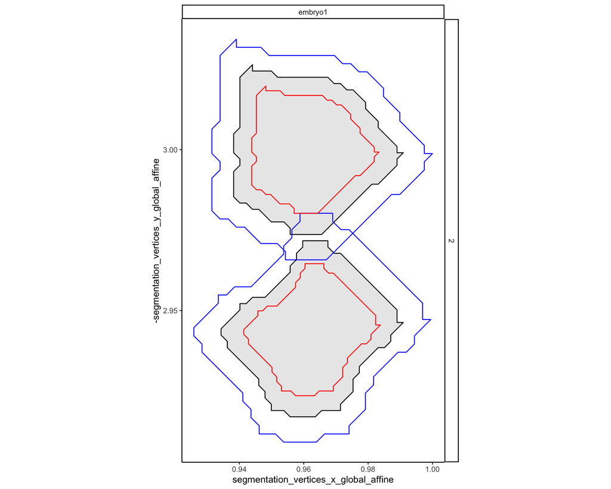

```r
g1 = g +
    geom_polygon(aes(x = segmentation_vertices_x_global_affine_expanded,
                     y = -segmentation_vertices_y_global_affine_expanded,
                     group = uniqueID),
                 fill = NA, colour = "blue",
                 inherit.aes = FALSE) +
    geom_polygon(aes(x = segmentation_vertices_x_global_affine_contracted,
                     y = -segmentation_vertices_y_global_affine_contracted,
                     group = uniqueID),
                 fill = NA, colour = "red",
                 inherit.aes = FALSE) +
    NULL
g1
```

Since the blue lines overlap with each other, these two cells will be marked as neighbouring, and an edge will be assigned to them in the output network.

```r
# boundary_polygons_tmp = subset(boundary_polygons, pos %in% c("Pos0", "Pos50"))

# boundary_polygons_split = split.data.frame(boundary_polygons_tmp,
#                                            boundary_polygons_tmp$embryo)

# keeps z-stacks together
# boundary_polygons_split = split.data.frame(boundary_polygons,
#                                            boundary_polygons$embryo)

# keeps z-stacks separate
boundary_polygons_split = split.data.frame(boundary_polygons,
                                           interaction(boundary_polygons$embryo,
                                                       boundary_polygons$z))

verticesDFList = lapply(boundary_polygons_split, function(df) {
    split.data.frame(df,df$uniqueID)
})
```

# Calculate neighbourhood graph

Perform this calculation for each embryo separately. We can imagine performing this calculation over multiple embryos with a large enough expansion factor, since the embryos are roughly aligned using affine transformation, so various tissue regions do overlap with each other.

```r
out_graph_filename = paste0("../analysis_output/E8.5/E8.5_neighbourGraph_",
                            expansionFactor,
                            ".Rds")

if (!file.exists(out_graph_filename)) {
    # function call for a single list element
    # out = neighbourVertices(verticesDFList[[1]],
    #                         xname = "segmentation_vertices_x_global_affine",
    #                         yname = "segmentation_vertices_y_global_affine",
    #                         expansionFactor = expansionFactor,
    #                         plot = FALSE,
    #                         plot2 = TRUE,
    #                         full = FALSE,
    #                         verbose = TRUE)

    if (FALSE) {
    out_list = lapply(verticesDFList,
                      neighbourVertices,
                      xname = "segmentation_vertices_x_global_affine",
                      yname = "segmentation_vertices_y_global_affine",
                      expansionFactor = expansionFactor,
                      plot = FALSE,
                      plot2 = FALSE,
                      full = FALSE,
                      verbose = TRUE)
    } else {
     out_list = parallel::mclapply(verticesDFList,
                      neighbourVertices,
                      xname = "segmentation_vertices_x_global_affine",
                      yname = "segmentation_vertices_y_global_affine",
                      expansionFactor = expansionFactor,
                      plot = FALSE,
                      plot2 = FALSE,
                      full = FALSE,
                      verbose = TRUE, mc.cores = 6)
    }

    out_graph = do.call(graph.union, out_list)
    saveRDS(out_graph, file = out_graph_filename)
}
```

# Classify mRNA dots from mRNA_df as inside or outside boundary regions

Load mRNA data. Subset down to z-stacks 2 and 5

```r
mRNA_df_filt = readRDS("../analysis_output/E8.5/E8.5_mRNA_df_filt.Rds")
# mRNA_df_filt <- subset(mRNA_df, z %in% c(2,5))
mRNA_df_filt$internal <- rep(FALSE, nrow(mRNA_df_filt))
```

Get contracted polygons, these are already subsetted to z-stacks 2 and 5.

```r
# contraction
boundary_polygons_contracted <- addExpandedVertices(boundary_polygons,
                                                 expansionFactor = contractionFactor,
                                                 new_xname = "segmentation_vertices_x_global_affine_contracted",
                                                 new_yname = "segmentation_vertices_y_global_affine_contracted")

verticesDFList_contracted = split.data.frame(boundary_polygons_contracted,
                                             boundary_polygons_contracted$uniqueID)
```

Take each polygon and class mRNA dots as to whether they are inside the polygon. This is an easier problem because we can automatically restrict to the mRNAs that are associated with the same cell. A value of TRUE means that the mRNA dot is internal to the cell.

```r
mRNA_df_filt_filename = paste0("../analysis_output/E8.5/E8.5_mRNA_df_internal_",
                               contractionFactor,
                               ".Rds")

uniqueIDs = mixedsort(unique(as.character(boundary_polygons$uniqueID)))

if (!file.exists(mRNA_df_filt_filename)) {
    for (uniqueID in uniqueIDs) {

        print(uniqueID)

        mRNA_df_filt_ind = which(mRNA_df_filt$uniqueID == uniqueID)

        inPoly = inpolygon(
            mRNA_df_filt$x_global_affine[mRNA_df_filt_ind],
            mRNA_df_filt$y_global_affine[mRNA_df_filt_ind],
            verticesDFList_contracted[[uniqueID]][,"segmentation_vertices_x_global_affine_contracted"],
            verticesDFList_contracted[[uniqueID]][,"segmentation_vertices_y_global_affine_contracted"],
            boundary = TRUE)

        mRNA_df_filt[mRNA_df_filt_ind, "internal"] <- inPoly

    }

    saveRDS(mRNA_df_filt, file = mRNA_df_filt_filename)
} else {
    mRNA_df_filt <- readRDS(mRNA_df_filt_filename)
}
```

Examine this a little using the example from before

```r
table(mRNA_df_filt$internal)
```

```
##
##   FALSE    TRUE
## 6928086 4076212
```

```r
head(mRNA_df_filt)
```

```
##   cellID geneID regionID        x        y z seeds intensity  pos   fov  embryo
## 1    135  Abcc4        1  670.522  423.266 2     4       671 Pos0 fov.1 embryo1
## 2     95  Abcc4        2  458.830 1637.477 2     4      1497 Pos0 fov.1 embryo1
## 3    326  Abcc4        3 1503.623  436.123 2     4       459 Pos0 fov.1 embryo1
## 4    280  Abcc4        4 1273.170 1287.838 2     3      1504 Pos0 fov.1 embryo1
## 5    168  Abcc4        5  793.611 1096.647 2     4       338 Pos0 fov.1 embryo1
## 6     25  Abcc4        6   92.681  324.985 2     4      1989 Pos0 fov.1 embryo1
##   Estage                uniqueID x_global y_global x_global_affine
## 1   E8.5 embryo1_Pos0_cell135_z2 1627.150 1335.407       1.0292865
## 2   E8.5  embryo1_Pos0_cell95_z2 1623.945 1353.786       0.9259213
## 3   E8.5 embryo1_Pos0_cell326_z2 1639.760 1335.601       1.4360741
## 4   E8.5 embryo1_Pos0_cell280_z2 1636.272 1348.494       1.3235482
## 5   E8.5 embryo1_Pos0_cell168_z2 1629.013 1345.600       1.0893885
## 6   E8.5  embryo1_Pos0_cell25_z2 1618.403 1333.919       0.7471376
##   y_global_affine   embryo_pos   embryo_pos_z internal
## 1       -3.294310 embryo1_Pos0 embryo1_Pos0_2    FALSE
## 2       -2.701434 embryo1_Pos0 embryo1_Pos0_2    FALSE
## 3       -3.288033 embryo1_Pos0 embryo1_Pos0_2    FALSE
## 4       -2.872156 embryo1_Pos0 embryo1_Pos0_2    FALSE
## 5       -2.965511 embryo1_Pos0 embryo1_Pos0_2    FALSE
## 6       -3.342299 embryo1_Pos0 embryo1_Pos0_2     TRUE
```

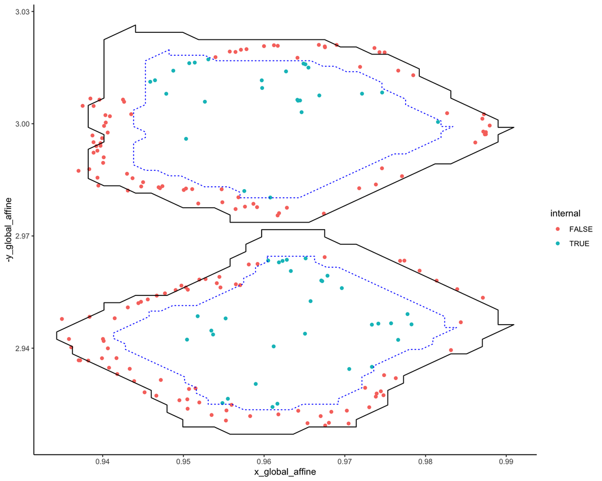

```r
ggplot(subset(mRNA_df_filt, uniqueID %in% boundary_polygons_example$uniqueID),
       aes(x = x_global_affine, y = -y_global_affine,
           colour = internal)) +
    geom_point() +
    geom_polygon(data = boundary_polygons_example,
                 aes(x = segmentation_vertices_x_global_affine,
                     y = -segmentation_vertices_y_global_affine,
                     group = uniqueID),
                 inherit.aes = FALSE,
                 colour = "black", fill = NA) +
    geom_polygon(data = boundary_polygons_example,
                 aes(x = segmentation_vertices_x_global_affine_contracted,
                     y = -segmentation_vertices_y_global_affine_contracted,
                     group = uniqueID),
                 inherit.aes = FALSE,
                 colour = "blue", fill = NA, linetype = "dotted") +
    theme_classic() +
    NULL
```

Some mRNA dots sit outside of the cell polygon boundary, but have been assigned to the cell - I think there’s likely to be some extremely subtle shift in aligning the segmentation and coordinates, also that the segmentation is performed on a 512x512 grid so lacks some resolution.

Generate expression array with three dimensions, genes x cells x internal status

```r
counts_arr = tapply(mRNA_df_filt[,1], list(
    mRNA_df_filt$geneID,
    mRNA_df_filt$uniqueID,
    mRNA_df_filt$internal
), length)
counts_arr[is.na(counts_arr)] <- 0

class(counts_arr)
```

```
## [1] "array"
```

```r
dim(counts_arr)
```

```
## [1]   351 57536     2
```

```r
lapply(dimnames(counts_arr),head)
```

```
## [[1]]
## [1] "Abcc4"   "Acp5"    "Acvr1"   "Acvr2a"  "Adora2b" "Afp"
##
## [[2]]
## [1] "embryo1_Pos0_cell10_z2"  "embryo1_Pos0_cell10_z5"
## [3] "embryo1_Pos0_cell100_z2" "embryo1_Pos0_cell100_z5"
## [5] "embryo1_Pos0_cell101_z2" "embryo1_Pos0_cell101_z5"
##
## [[3]]
## [1] "FALSE" "TRUE"
```

```r
counts_arr[1:5,1:5,]
```

```
## , , FALSE
##
##         embryo1_Pos0_cell10_z2 embryo1_Pos0_cell10_z5 embryo1_Pos0_cell100_z2
## Abcc4                        0                      0                       0
## Acp5                         0                      0                       1
## Acvr1                        1                      0                       0
## Acvr2a                       0                      0                       0
## Adora2b                      0                      0                       0
##         embryo1_Pos0_cell100_z5 embryo1_Pos0_cell101_z2
## Abcc4                         0                       0
## Acp5                          0                       1
## Acvr1                         0                       0
## Acvr2a                        1                       1
## Adora2b                       1                       0
##
## , , TRUE
##
##         embryo1_Pos0_cell10_z2 embryo1_Pos0_cell10_z5 embryo1_Pos0_cell100_z2
## Abcc4                        0                      0                       0
## Acp5                         3                      0                       1
## Acvr1                        0                      0                       0
## Acvr2a                       0                      0                       0
## Adora2b                      0                      0                       0
##         embryo1_Pos0_cell100_z5 embryo1_Pos0_cell101_z2
## Abcc4                         0                       0
## Acp5                          0                       0
## Acvr1                         1                       0
## Acvr2a                        0                       0
## Adora2b                       0                       0
```

Brief comparison, add a jitter to be able to see points

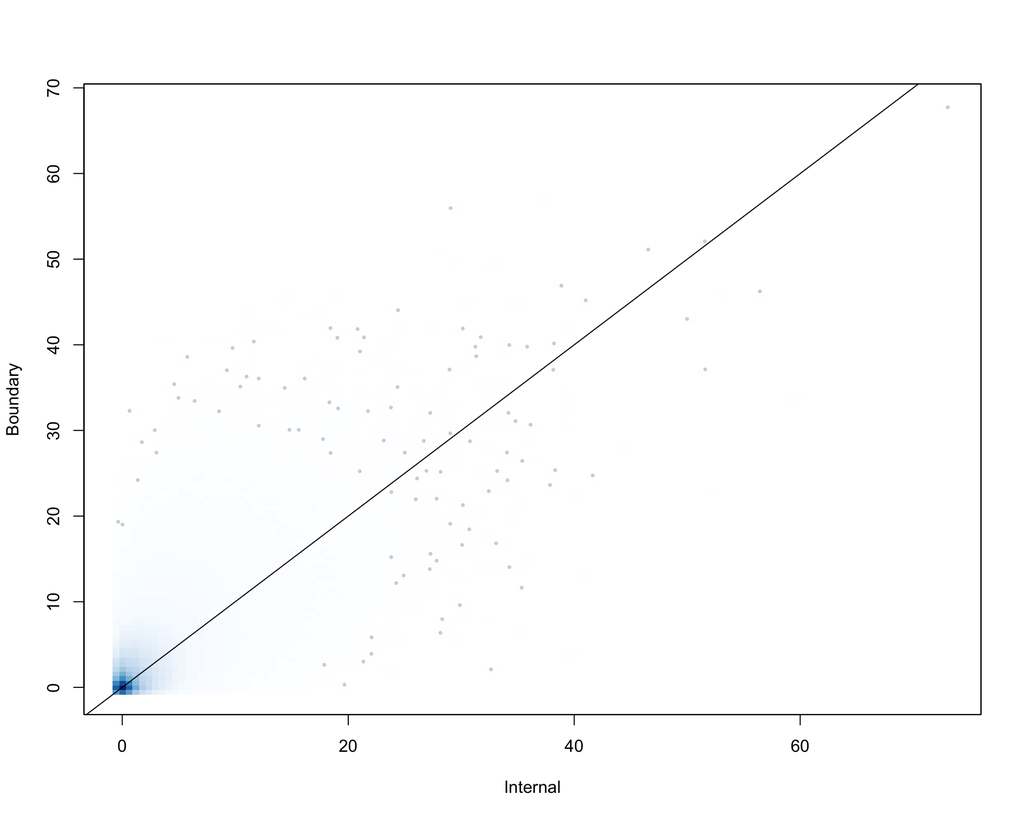

```r
smoothScatter(c(jitter(counts_arr[,,"TRUE"], amount = 0.45)),
     c(jitter(counts_arr[,,"FALSE"], amount = 0.45)),
     pch = 16, cex = 0.5,
     col = scales::alpha("black", 0.2),
     xlab = "Internal", ylab = "Boundary", gridsize = 15)
abline(c(0,1))
```

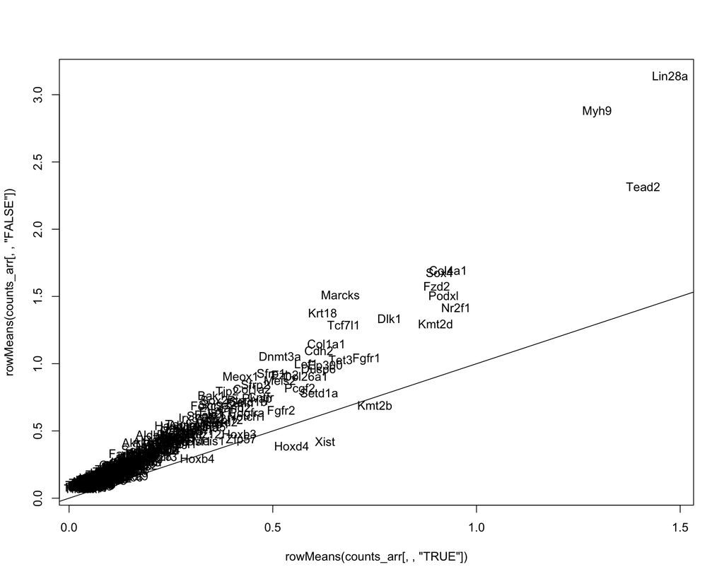

```r
plot(rowMeans(counts_arr[,,"TRUE"]),
     rowMeans(counts_arr[,,"FALSE"]), type = "n")
abline(c(0,1))
text(rowMeans(counts_arr[,,"TRUE"]),
     rowMeans(counts_arr[,,"FALSE"]),
     labels = rownames(counts_arr))
```

```r
# names(which(rowMeans(counts_arr[,,"FALSE"]) > rowMeans(counts_arr[,,"TRUE"])))
```